# NYPD Shooting Incident Analysis

```r
# library packages
library(tidyverse)
library(data.table)
library(lubridate)
library(mltools)
```

### Reading in and exploring data:

```r
#read in data from reproducible pathway
raw_data = fread('data/NYPD_Shooting_Incident_Data__Historic_.csv')
head(raw_data)
```

| INCIDENT_KEY | OCCUR_DATE | OCCUR_TIME | BORO | PRECINCT | JURISDICTION_CODE | LOCATION_DESC | STATISTICAL_MURDER_FLAG | PERP_AGE_GROUP | PERP_SEX | PERP_RACE | VIC_AGE_GROUP | VIC_SEX | VIC_RACE | X_COORD_CD | Y_COORD_CD | Latitude | Longitude | Lon_Lat |
| --- | --- | --- | --- | --- | --- | --- | --- | --- | --- | --- | --- | --- | --- | --- | --- | --- | --- | --- |
| 24050482 | 08/27/2006 | 05:35:00 | BRONX | 52 | 0 |  | TRUE |  |  |  | 25-44 | F | BLACK HISPANIC | 1017542 | 255918.9 | 40.86906 | -73.87963 | POINT (-73.87963173099996 40.86905819000003) |
| 77673979 | 03/11/2011 | 12:03:00 | QUEENS | 106 | 0 |  | FALSE |  |  |  | 65+ | M | WHITE | 1027543 | 186095.0 | 40.67737 | -73.84392 | POINT (-73.84392019199998 40.677366895000034) |
| 226950018 | 04/14/2021 | 21:08:00 | BRONX | 42 | 0 | COMMERCIAL BLDG | TRUE |  |  |  | 18-24 | M | BLACK | 1009489 | 243050.0 | 40.83376 | -73.90880 | POINT (-73.90879517699994 40.83376365400005) |
| 237710987 | 12/10/2021 | 19:30:00 | BRONX | 52 | 0 |  | FALSE |  |  |  | 25-44 | M | BLACK | 1017440 | 256046.0 | 40.86941 | -73.88000 | POINT (-73.87999831299999 40.86940749200004) |
| 224701998 | 02/22/2021 | 00:18:00 | MANHATTAN | 34 | 0 |  | FALSE |  |  |  | 25-44 | M | BLACK HISPANIC | 1005426 | 254690.0 | 40.86572 | -73.92344 | POINT (-73.92344088699997 40.86572268100008) |
| 225295736 | 03/07/2021 | 06:15:00 | BROOKLYN | 75 | 0 |  | TRUE | 25-44 | M | BLACK HISPANIC | 25-44 | M | WHITE HISPANIC | 1020492 | 187865.0 | 40.68226 | -73.86933 | POINT (-73.86933111399996 40.68225681500007) |

### Summary of the raw data:

```r
summary(raw_data)
```

```
##   INCIDENT_KEY        OCCUR_DATE         OCCUR_TIME            BORO
##  Min.   :  9953245   Length:25596       Length:25596       Length:25596
##  1st Qu.: 61593633   Class :character   Class :character   Class :character
##  Median : 86437258   Mode  :character   Mode  :character   Mode  :character
##  Mean   :112382648
##  3rd Qu.:166660833
##  Max.   :238490103
##
##     PRECINCT      JURISDICTION_CODE LOCATION_DESC      STATISTICAL_MURDER_FLAG
##  Min.   :  1.00   Min.   :0.0000    Length:25596       Mode :logical
##  1st Qu.: 44.00   1st Qu.:0.0000    Class :character   FALSE:20668
##  Median : 69.00   Median :0.0000    Mode  :character   TRUE :4928
##  Mean   : 65.87   Mean   :0.3316
##  3rd Qu.: 81.00   3rd Qu.:0.0000
##  Max.   :123.00   Max.   :2.0000
##                   NA's   :2
##  PERP_AGE_GROUP       PERP_SEX          PERP_RACE         VIC_AGE_GROUP
##  Length:25596       Length:25596       Length:25596       Length:25596
##  Class :character   Class :character   Class :character   Class :character
##  Mode  :character   Mode  :character   Mode  :character   Mode  :character
##
##
##
##
##    VIC_SEX            VIC_RACE           X_COORD_CD        Y_COORD_CD
##  Length:25596       Length:25596       Min.   : 914928   Min.   :125757
##  Class :character   Class :character   1st Qu.:1000011   1st Qu.:182782
##  Mode  :character   Mode  :character   Median :1007715   Median :194038
##                                        Mean   :1009455   Mean   :207894
##                                        3rd Qu.:1016838   3rd Qu.:239429
##                                        Max.   :1066815   Max.   :271128
##
##     Latitude       Longitude        Lon_Lat
##  Min.   :40.51   Min.   :-74.25   Length:25596
##  1st Qu.:40.67   1st Qu.:-73.94   Class :character
##  Median :40.70   Median :-73.92   Mode  :character
##  Mean   :40.74   Mean   :-73.91
##  3rd Qu.:40.82   3rd Qu.:-73.88
##  Max.   :40.91   Max.   :-73.70
##
```

### Summary of columns of interest:

```r
table(raw_data$STATISTICAL_MURDER_FLAG)
```

```
##
## FALSE  TRUE
## 20668  4928
```

```r
table(raw_data$PERP_RACE)
```

```
##
##                                AMERICAN INDIAN/ALASKAN NATIVE
##                           9310                              2
##       ASIAN / PACIFIC ISLANDER                          BLACK
##                            141                          10668
##                 BLACK HISPANIC                        UNKNOWN
##                           1203                           1836
##                          WHITE                 WHITE HISPANIC
##                            272                           2164
```

Noteworthy that there are both null and ‘UNKNOWN’ Values in PERP_RACE.

```r
table(raw_data$BORO)
```

```
##
##         BRONX      BROOKLYN     MANHATTAN        QUEENS STATEN ISLAND
##          7402         10365          3265          3828           736
```

##### Is INCIDENT_KEY the primary key?

```r
#number of rows in raw data:
print(nrow(raw_data))
```

```
## [1] 25596
```

```r
#number of unique INCIDENT_KEY
ind_key = raw_data[,.(INCIDENT_KEY)]
ind_key = distinct(ind_key)
print(nrow(ind_key))
```

```
## [1] 20126
```

Answer: No, INCIDENT_KEY is not the primary key. one INCIDENT_KEY can be seen on more than one record.

## Where are there the most murders?

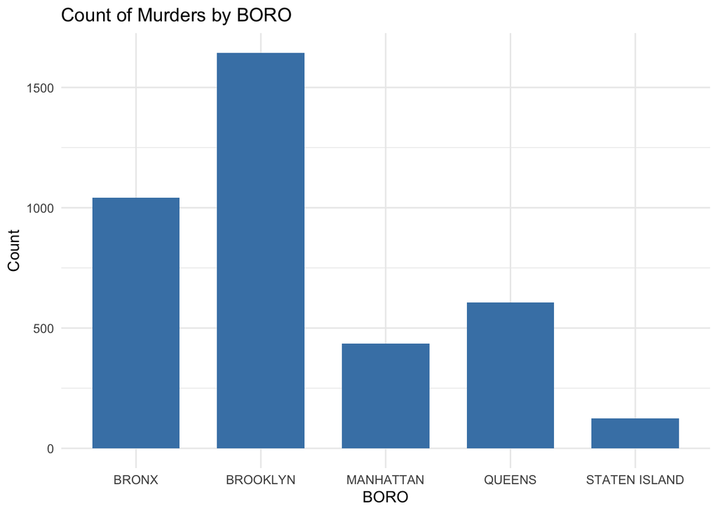

```r
#create a data table that only contains incidents that had a murder.
murders_only = raw_data[STATISTICAL_MURDER_FLAG == TRUE]

#since we know counting the lines would not be the distinct count of incidents, we need to handle that.
murders_only = murders_only[,.(INCIDENT_KEY, OCCUR_DATE, BORO) ]
murders_only = distinct(murders_only)

#graph
ggplot(murders_only, aes(x=factor(BORO)))+
  geom_bar(stat="count", width=0.7, fill="steelblue")+
  theme_minimal() + ggtitle("Count of Murders by BORO") +
  xlab("BORO") + ylab("Count")
```

Looks like the most murders occur in Brooklyn and the Bronx in total, but I wonder what the results will show if we look at this over time.

## Murders over time by BORO:

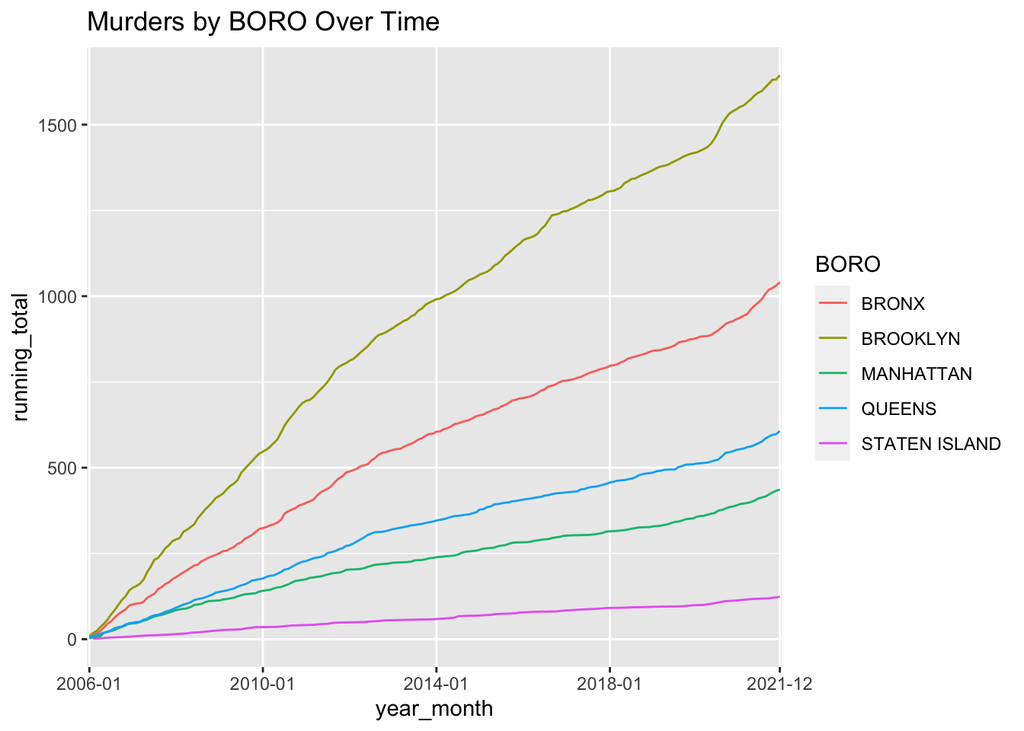

```r
# OCCUR_DATE was read in as a character, so we will need convert it to a date format so that we can graph it.
murder_over_time = raw_data[STATISTICAL_MURDER_FLAG == TRUE]
murder_over_time[,date:= as.Date(OCCUR_DATE, format = "%m/%d/%Y")]
murder_over_time[,year_month:= format(as.Date(date), "%Y-%m")]


# now I will want to create a column that is a running total of incidents by BORO and year_month:
#limit columns to the ones we need and get distinct records:
murder_over_time_distinct = murder_over_time[,.(INCIDENT_KEY, year_month, BORO) ]
murder_over_time_distinct = distinct(murder_over_time_distinct)

#create count column and get distinct records:
setorder(murder_over_time_distinct, BORO,year_month)
murder_over_time_distinct[,count_of_murder_per_month:= .N, by = .( BORO, year_month)]
murder_over_time_distinct = murder_over_time_distinct[,.(BORO,year_month,count_of_murder_per_month) ]
murder_over_time_distinct = distinct(murder_over_time_distinct)

# cumulative sum (running total):
setorder(murder_over_time_distinct, BORO,year_month)
murder_over_time_distinct[,running_total:= cumsum(count_of_murder_per_month), by = .( BORO)]
#line plot:
ggplot(murder_over_time_distinct, aes(x= year_month, y=running_total, group=BORO, color=BORO)) +
  geom_line()  + scale_x_discrete(breaks = c('2006-01','2010-01','2014-01','2018-01','2021-12')) + ggtitle("Murders by BORO Over Time")
```

In the end the results from graphing the murders over time is pretty similar to the bar graph. There does seem to be instances where the rate of murders increases.

## Can we predict if an incident results in a murder?

STATISTICAL_MURDER_FLAG will be the response that is going to be predicted.

I selected features mostly based on that they didn’t have many null values.

```r
#limit data set to columns that will be made into features.
features = raw_data[,.(OCCUR_DATE, BORO, VIC_RACE, VIC_SEX, STATISTICAL_MURDER_FLAG) ]

#create date type col and remove OCCUR_DATE:
features[,date:= as.Date(OCCUR_DATE, format = "%m/%d/%Y")]
features[,OCCUR_DATE:=NULL]

#convert the columns that need to be one hot encoded into factors:
features$BORO <- as.factor(features$BORO)
features$VIC_RACE <- as.factor(features$VIC_RACE)
features$VIC_SEX <- as.factor(features$VIC_SEX)

# One hot encode:
features_ohe = one_hot(as.data.table(features))
features_ohe = distinct(features_ohe)

#fill null values with 0:
features_ohe[is.na(features_ohe)] = 0


# split data into training and testing data by date.
train  = features_ohe[ date < '2021-01-01']
test  = features_ohe[ date >= '2021-01-01']

#remove date from train and test data tables:
train[,date:=NULL]
test[,date:=NULL]
```

Now training the model and looking at the some results from training!

```r
model <- glm(STATISTICAL_MURDER_FLAG ~.,family=binomial(link='logit'),data=train)
summary(model)
```

```
##
## Call:
## glm(formula = STATISTICAL_MURDER_FLAG ~ ., family = binomial(link = "logit"),
##     data = train)
##
## Deviance Residuals:
##     Min       1Q   Median       3Q      Max
## -0.8899  -0.7095  -0.6737  -0.5906   2.1262
##
## Coefficients: (3 not defined because of singularities)
##                                            Estimate Std. Error z value Pr(>|z|)
## (Intercept)                                -2.00546    1.08432  -1.850 0.064383
## BORO_BRONX                                  0.06388    0.11014   0.580 0.561933
## BORO_BROOKLYN                               0.26721    0.10778   2.479 0.013164
## BORO_MANHATTAN                             -0.08306    0.11714  -0.709 0.478287
## BORO_QUEENS                                 0.07047    0.11381   0.619 0.535778
## `BORO_STATEN ISLAND`                             NA         NA      NA       NA
## `VIC_RACE_AMERICAN INDIAN/ALASKAN NATIVE` -11.23685  114.65462  -0.098 0.921927
## `VIC_RACE_ASIAN / PACIFIC ISLANDER`         0.18318    0.14954   1.225 0.220605
## VIC_RACE_BLACK                              0.05139    0.05375   0.956 0.339041
## `VIC_RACE_BLACK HISPANIC`                  -0.29073    0.07948  -3.658 0.000254
## VIC_RACE_UNKNOWN                           -0.63589    0.41405  -1.536 0.124590
## VIC_RACE_WHITE                              0.44217    0.10703   4.131 3.61e-05
## `VIC_RACE_WHITE HISPANIC`                        NA         NA      NA       NA
## VIC_SEX_F                                   0.43594    1.07949   0.404 0.686329
## VIC_SEX_M                                   0.57423    1.07796   0.533 0.594241
## VIC_SEX_U                                        NA         NA      NA       NA
##
## (Intercept)                               .
## BORO_BRONX
## BORO_BROOKLYN                             *
## BORO_MANHATTAN
## BORO_QUEENS
## `BORO_STATEN ISLAND`
## `VIC_RACE_AMERICAN INDIAN/ALASKAN NATIVE`
## `VIC_RACE_ASIAN / PACIFIC ISLANDER`
## VIC_RACE_BLACK
## `VIC_RACE_BLACK HISPANIC`                 ***
## VIC_RACE_UNKNOWN
## VIC_RACE_WHITE                            ***
## `VIC_RACE_WHITE HISPANIC`
## VIC_SEX_F
## VIC_SEX_M
## VIC_SEX_U
## ---
## Signif. codes:  0 '***' 0.001 '**' 0.01 '*' 0.05 '.' 0.1 ' ' 1
##
## (Dispersion parameter for binomial family taken to be 1)
##
##     Null deviance: 17398  on 16751  degrees of freedom
## Residual deviance: 17288  on 16739  degrees of freedom
## AIC: 17314
##
## Number of Fisher Scoring iterations: 11
```

Test the model trained above on hold out data.

```r
# Use the model on the test set.
fitted.results <- predict(model,newdata=subset(test,select=c(1:15)),type='response')
# Use 0.5 as the cutoff probability
binarized_results <- ifelse(fitted.results > 0.5,1,0)
misClasificError <- mean(binarized_results != test$STATISTICAL_MURDER_FLAG)
print(paste('Accuracy',1-misClasificError))
```

```
## [1] "Accuracy 0.764540995094604"
```

76% accurate isn’t too bad!

However this is a bit misleading! Below shows that all the binary results are 0!

```r
summary(binarized_results)
```

```
##    Min. 1st Qu.  Median    Mean 3rd Qu.    Max.
##       0       0       0       0       0       0
```

Lets look at a distribution of the probabilities to learn more.

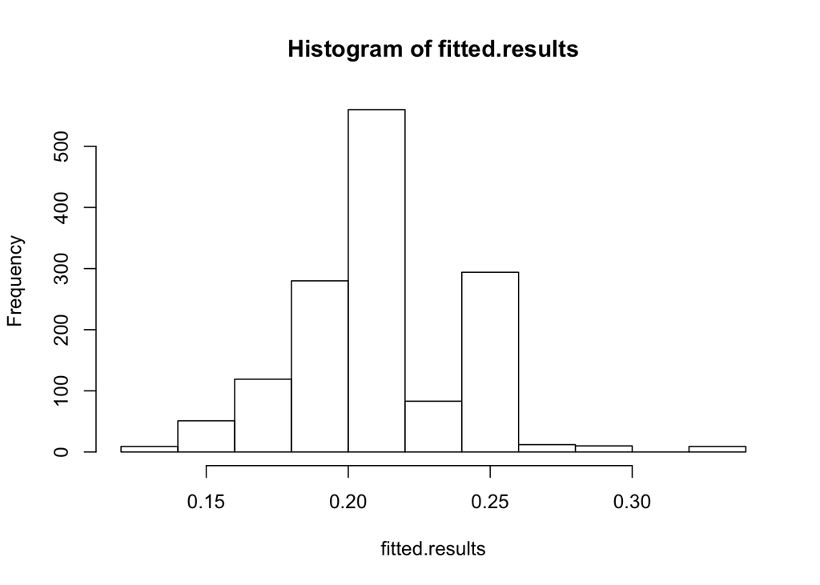

```r
hist(fitted.results)
```

Lets find the median and use that to binarize our probabilities on.

```r
summary(fitted.results)
```

```
##    Min. 1st Qu.  Median    Mean 3rd Qu.    Max.
##  0.1253  0.1880  0.2115  0.2091  0.2379  0.3270
```

```r
binarized_results <- ifelse(fitted.results > 0.2115,1,0)
misClasificError <- mean(binarized_results != test$STATISTICAL_MURDER_FLAG)
print(paste('Accuracy',1-misClasificError))
```

```
## [1] "Accuracy 0.557112824106517"
```

Unsurprisingly the Accuracy goes down as we increase the number of positive predictions in a low prevalence response. Accuracy is just one metric. If I were to continue this project, I would want to look at precision, recall, and ROC AUC. However I feel that is out of the scope of this project.

### Conclusion:

This was an interesting project. I probably would have never worked with data about shooting incidents if it weren’t for this exercise. For whatever reason I was initially drawn to the STATISTICAL_MURDER_FLAG as an interesting data element in the data set and thus most of my analysis was centered about it.

The fact that I choose to focus on this data element might be a source of bias for my project. People who read my analysis might conclude that Brooklyn has the most gun related crime. This may or may not be true, but from just my analysis it is unknown. We have no information about the population size of these cities and thus no understanding of the crime rate relative to population.

My first two graphs only focus on incidents that ended in murder, but I never compared the murder cases to the total cases from that city. This could be another source of bias in my analysis.

One last thing I noticed about the data set is that often the column about the perpetrator are null. If someone did anlysis on these columns, that would surely be a source of bias as so much of this data is not reported. This is why I decided to stay away from these columns in my analysis.